# A Tutorial in Data Science Using League of Legends Data

By Tyler Han

## Introduction

Hi reader! As a final project for my data science class, I've been tasked with creating a tutorial demonstrating some uses of the data science techniques that we learned from class. In this tutorial, we'll be covering DataFrames, Data Visualization, and some Machine Learning concepts.

And since I've had some free time during quarantine, I've gone back to my old roots and begun playing some good ol' League of Legends again. So, I'll be using data from [Champion.gg](https://champion.gg/statistics/) for this tutorial.

Observing this data is not only fun but useful for understanding a game as complex as League. There are a countless number of games being played every second, yielding an absurd amount of data recorded over time. There may be a billion interactions between data points and perhaps some non-interactions which may surprise players. Regardless, studying this data in this tutorial is a good look into how data science may help shine light on some originally esoteric relationships.

## Packages and Libraries

You will need packages! I will be explaining how we use them as we go on but from what I've learned, the data science community has made huge leaps in developing open-source software for everyone's convenience. Let's take advantage of them!

```python
import pandas as pd
import matplotlib.pyplot as plt
import sklearn
import numpy as np
from bs4 import BeautifulSoup
import requests
import json
from copy import deepcopy
from sklearn.model_selection import train_test_split
from sklearn import linear_model
from sklearn.ensemble import RandomForestRegressor
import seaborn as sns
```

## Obtaining the Data

First things first, get the data! Some sites like Kaggle have convenient API and links to request certain data without much trouble, but the data I'll be trying to obtain is not so clean. We'll need beautifulsoup to help us grab the data and store it neatly inside a table so we can manipulate it later.

```python
r = requests.get("http://champion.gg/statistics/?league=platplus")
html = BeautifulSoup(r.content,"html")
```

Great! Now we've got the html describing that page containing all the data we want. Now we just have to select the relevant tags which indicate where the data is and we've got our table! In this case, our data is lying inside of the \<script> tags. If you're obtaining data from other places, this may not necessarily be the case, so you'll have to sift through the HTML to find what you want!

```python
script = html.findAll("script")
html_data = str(script[21])
```

So, looking at the table, we've got one champion per row and a bunch of matchup data in their columns- all separated and stored in JSON structure.

```python
sformat = '{%s}' % (html_data.split('{',1)[1].rsplit('}',1)[0])
sformat = '['+sformat+']'
sformat = sformat.replace('\'',"")
jsons = json.loads(sformat)
```

Now we have a JSON structure which we can plop into a data frame.

```python
df = pd.DataFrame(data = jsons)
df.head()
```

|  | general | key | role | title |
| --- | --- | --- | --- | --- |
| 0 | {'winPercent': 0.48990600299081394, 'playPerce... | Ezreal | ADC | Ezreal |
| 1 | {'winPercent': 0.48982334869431643, 'playPerce... | LeeSin | Jungle | Lee Sin |
| 2 | {'winPercent': 0.5025089605734767, 'playPercen... | Thresh | Support | Thresh |
| 3 | {'winPercent': 0.5139655988638157, 'playPercen... | Graves | Jungle | Graves |
| 4 | {'winPercent': 0.5086279264993937, 'playPercen... | Kayn | Jungle | Kayn |

Yikes! Not yet I guess. We'll need to split the general attribute up as well.

```python
njson = deepcopy(jsons)
for i in range(len(jsons)):
    for k,v in jsons[i].items():
        if k == "general":
            del njson[i][k]
            njson[i] = {**njson[i], **v}
df = pd.DataFrame(data = njson)
df.head()
```

|  | assists | banRate | deaths | experience | goldEarned | key | kills | largestKillingSpree | minionsKilled | neutralMinionsKilledEnemyJungle | neutralMinionsKilledTeamJungle | overallPosition | overallPositionChange | playPercent | role | title | totalDamageDealtToChampions | totalDamageTaken | totalHeal | winPercent |
| --- | --- | --- | --- | --- | --- | --- | --- | --- | --- | --- | --- | --- | --- | --- | --- | --- | --- | --- | --- | --- |
| 0 | 7.063662 | 0.007631 | 5.162305 | 8.023096 | 11748 | Ezreal | 6.528359 | 8 | 177.891583 | 1.878445 | 7.153012 | 5 | -3.0 | 0.150860 | ADC | Ezreal | 22562 | 17753 | 2176 | 0.489906 |
| 1 | 7.803315 | 0.018115 | 5.258449 | 11.933269 | 10320 | LeeSin | 6.129928 | 8 | 26.043587 | 8.888761 | 72.619624 | 5 | 1.0 | 0.125883 | Jungle | Lee Sin | 12307 | 26349 | 7763 | 0.489823 |
| 2 | 12.531443 | 0.012562 | 5.446986 | 10.618540 | 7436 | Thresh | 1.954578 | 4 | 32.323232 | 0.059563 | 0.064190 | 5 | -1.0 | 0.123636 | Support | Thresh | 6962 | 16334 | 1846 | 0.502509 |
| 3 | 7.029904 | 0.033897 | 4.863816 | 6.876998 | 11211 | Graves | 5.824286 | 9 | 48.041581 | 12.425911 | 85.605570 | 1 | 0.0 | 0.102115 | Jungle | Graves | 15918 | 22082 | 8004 | 0.513966 |
| 4 | 6.903927 | 0.019643 | 5.738737 | 4.802166 | 11000 | Kayn | 6.881541 | 9 | 35.955788 | 10.609645 | 82.525604 | 2 | 0.0 | 0.086380 | Jungle | Kayn | 16120 | 30912 | 14350 | 0.508628 |

That looks much better! So now we have a tidy dataset where every row is an entity (a champion) and every column represents some attribute of the entities. We can start visualizing what data is being held by this table.

## Data Visualization

I've been interested in the relationship between kills and win rate in my games. Let's see what that looks like. And since I know (as a support main) that for some roles it's not as important, let's distinguish those roles in the plot.

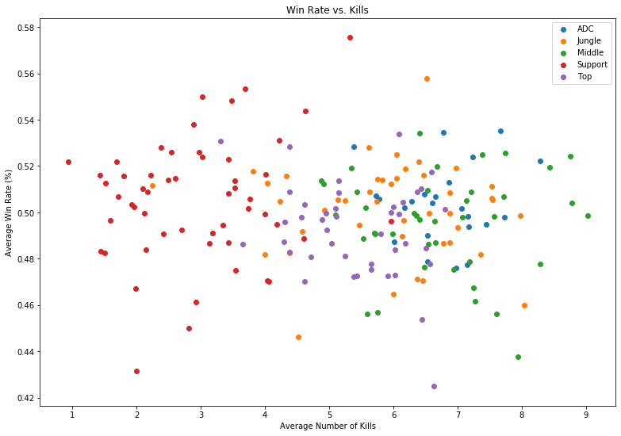

```python
fig,ax = plt.subplots(figsize=(13,9))
for role,group in df.groupby('role'):
    ax.scatter(group['kills'],group['winPercent'],label=role)

ax.set_title('Win Rate vs. Kills')
ax.legend()
ax.set_xlabel('Average Number of Kills')
ax.set_ylabel('Average Win Rate (%)')
plt.show()
```

Huh, I've noticed something about this plot. We'll look at it again later, but for now let's visualize some more!

I'm also curious as to whether people really ban champions that are annoying or just win a lot. Let's take a look at win rate vs ban rate. There's probably also some bearing in the position of the champion overall so we'll condition on that as well.

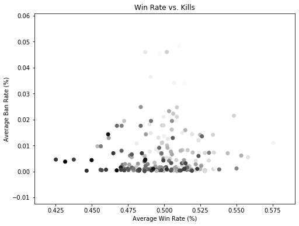

```python
x = df['winPercent']
y = df['banRate']
pos = df['overallPosition']
maxpos = max(pos)
color = [str(1.0 - (item/maxpos)) for item in pos]
fig,ax = plt.subplots(figsize=(8,6))
ax.scatter(x, y, c=color)
ax.set_title('Win Rate vs. Kills')
ax.set_xlabel('Average Win Rate (%)')
ax.set_ylabel('Average Ban Rate (%)')
plt.show()
```

Looks like there is some general trend indicaticating that higher posed champions are banned more often - but a surprising lack of correlation between win rate and ban rate. We can try and verify this hypothesis using linear regression.

# Machine Learning

## Linear Regression and Hypothesis Testing

Now that I think there won't be any relationship between these two variables. Let's test that shall we? We'll be looking to see if there isn't (or is) a statistically verifiable correlation term between win rate and ban rate. Meaning, we want to be "some amount of sure" (say $1 - \alpha = .95$) that a linearly regressed term $\beta$ between win rate and ban rate does not fit our observed data points.

Our model will look like:

$\mathrm{(Average~Ban~Rate)} = \beta_1 * \mathrm{(Average~Win~Rate)} + \beta_0$

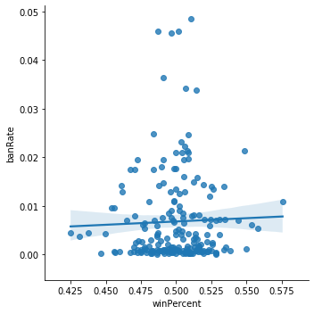

```python
reg = linear_model.LinearRegression()
x = np.array(df.winPercent).reshape(-1, 1)
y = np.array(df.banRate).reshape(-1, 1)
sns.lmplot(data=df, x="winPercent", y="banRate",fit_reg = True)
reg.fit(x,y)
plt.show()
```

```python
reg.score(x,y)
```

```
0.0011097400623254483
```

## Random Forests

Okay, linear regression is cool and all but have you ever seen a Random Forest? No, not a random forest - a Random Forest! Random Forests is a popular machine learning algorithm which uses a bunch of randomly initialized Decision Trees to predict classes.

[figure not shown]

The above is an illustration of a decision tree taken from my professor's lecture notes (https://www.hcbravo.org/IntroDataSci/bookdown-notes/tree-based-methods.html). This decision tree might be used to determine if a person's account defaults or not. These trees are pretty self-explanatory and so they're widely used for their simplicity and representational power. Of course, if you'd like to learn more, here's a good article: https://towardsdatascience.com/understanding-random-forest-58381e0602d2.

Remember the Win Rate vs Kills plot from above? I figured that there might be some way to determine the role based on those two attributes since the data appears to be grouped.

[figure not shown]

Champions in the Support role are very clearly grouped but what about the rest? Let's see if Random Forests can predict the role based on kills and win rate.

Let's first set up our dataframe for inserting it into the classifier.

```python
predictor_df = pd.get_dummies(df[['kills','winPercent','role']])
predictor_df.head()
```

|  | kills | winPercent | role_ADC | role_Jungle | role_Middle | role_Support | role_Top |
| --- | --- | --- | --- | --- | --- | --- | --- |
| 0 | 6.528359 | 0.489906 | 1 | 0 | 0 | 0 | 0 |
| 1 | 6.129928 | 0.489823 | 0 | 1 | 0 | 0 | 0 |
| 2 | 1.954578 | 0.502509 | 0 | 0 | 0 | 1 | 0 |
| 3 | 5.824286 | 0.513966 | 0 | 1 | 0 | 0 | 0 |
| 4 | 6.881541 | 0.508628 | 0 | 1 | 0 | 0 | 0 |

```python
labels = np.array(predictor_df[['role_ADC','role_Jungle','role_Middle','role_Support','role_Top']])
predictor_df = predictor_df.drop(['role_ADC','role_Jungle','role_Middle','role_Support','role_Top'],axis=1)
feature_list = list(predictor_df.columns)
features = np.array(predictor_df)
```

Now let's split the data into training and testing sets.

```python
train_features,test_features,train_labels,test_labels = train_test_split(features,labels,test_size=.25,random_state=42)
```

And now train the dataset.

```python
rf = RandomForestRegressor(n_estimators=100,random_state=42)
rf.fit(train_features,train_labels)
predictions = rf.predict(test_features)
errors = abs(predictions - test_labels)

print('Mean Absolute Error: ' + str(round(np.mean(errors),2)))
```

```
Mean Absolute Error: 0.2
```

So, it seems to have a pretty high success rate! For fun, let's predict my last couple ranked games (yes, I did just choose some games I did well in).

[figure not shown]

```python
print("Game 1 prediction: ")
print(rf.predict(np.array([0,.511]).reshape(1, -1)))
print("Game 2 prediction: ")
print(rf.predict(np.array([5,.255]).reshape(1, -1)))
print("Game 3 prediction: ")
print(rf.predict(np.array([3,.67]).reshape(1, -1)))
```

```
Game 1 prediction:
[[0.   0.12 0.   0.88 0.  ]]
Game 2 prediction:
[[0.   0.05 0.37 0.   0.58]]
Game 3 prediction:
[[0. 0. 0. 1. 0.]]
```

So it guessed that for my first game, there was an 88% chance I was playing support. For my second game, it though I was either top or middle. And for my last game it thought I was definitely support.

## Conclusion

There are tons of other relationships to be looked at and data science techniques are a great way to visualize and communicate these characteristics. If you'd like to learn more about machine learning and data science, my favorite website to learn the relevant mathematics and practices is Medium's "Toward Data Science" blog (https://towardsdatascience.com/).